# Project

Monika Kaczan, Katarzyna Jalbrzykowska

05 June 2022

## Classification: drugs

### Data preparation

#### General

Firstly, we loaded the data, checked how they look like and whether there are any missing observations. We dropped the id column.

```r
drugs <- read_csv("drugs_train.csv")
drugs_to_test <- read_csv("drugs_test.csv")
any(is.na(drugs))
```

```
## [1] FALSE
```

```r
drugs <- subset(drugs, select = -c(id) )
glimpse(drugs)
```

```
## Rows: 1,500
## Columns: 20
## $ age                            <chr> "45-54", "25-34", "18-24", "25-34", "18~
## $ gender                         <chr> "male", "male", "female", "female", "ma~
## $ education                      <chr> "Masters degree", "University degree", ~
## $ country                        <chr> "USA", "USA", "USA", "USA", "Australia"~
## $ ethnicity                      <chr> "Mixed-Black/Asian", "Mixed-Black/Asian~
## $ personality_neuroticism        <dbl> 57.6, 47.8, 57.6, 71.8, 56.1, 47.8, 75.~
## $ personality_extraversion       <dbl> 57.3, 67.0, 43.3, 31.2, 62.3, 20.7, 69.~
## $ personality_openness           <dbl> 50.1, 45.7, 55.3, 43.6, 70.2, 57.8, 62.~
## $ personality_agreeableness      <dbl> 47.8, 47.8, 45.6, 56.3, 66.1, 41.2, 54.~
## $ personality_conscientiousness  <dbl> 53.7, 56.0, 49.9, 31.8, 42.4, 33.6, 38.~
## $ personality_impulsiveness      <dbl> 42.8, 33.8, 63.0, 63.0, 50.4, 56.5, 56.~
## $ personality_sensation          <dbl> 22.4, 30.8, 62.0, 71.1, 62.0, 62.0, 22.~
## $ consumption_alcohol            <chr> "used in last week", "used in last week~
## $ consumption_amphetamines       <chr> "used over a decade ago", "never used",~
## $ consumption_caffeine           <chr> "used in last day", "used in last week"~
## $ consumption_cannabis           <chr> "used in last week", "never used", "use~
## $ consumption_chocolate          <chr> "used in last day", "used in last day",~
## $ consumption_mushrooms          <chr> "never used", "never used", "used in la~
## $ consumption_nicotine           <chr> "used in last week", "never used", "use~
## $ consumption_cocaine_last_month <chr> "No", "No", "No", "No", "No", "No", "Ye~
```

#### Ordinal and categorical variables

As ordinal and categorical variables are stored as characters, we needed to convert it to factors.

Most people are either from Australia or USA. Other countries (Canada, Ireland, UK and New Zeland) all have under 10% of representation. Therefore we decided to include them as “Other”.

```r
table(drugs$country)
```

```
##
##   Australia      Canada     Ireland New Zealand       Other          UK
##         460           5          13          94          44          73
##         USA
##         811
```

```r
drugs$country[drugs$country %in% c("Canada","Ireland", "UK", "New Zealand")] <- "Other"
drugs$country <- as.factor(drugs$country)
```

Over 90% of observations are Mixed-Black/Asian which suggest that our data is quite homogeneous. Therefore we decided to drop variable ethnicity from our data.

```r
table(drugs$ethnicity)
```

```
##
##             Asian             Black Mixed-Black/Asian Mixed-White/Asian
##                25                22              1372                15
## Mixed-White/Black             Other             White
##                47                16                 3
```

```r
drugs <- subset(drugs, select = -c(ethnicity) )
```

Some categories describing age and consumption of different drugs have very few observations compared to others. This is why we decided to merge selected categories which we believed presented similar data. This includes:  
- merging Canada, Ireland, UK and New Zealand to ‘Other’ in variable ‘country’  
- merging 55-64 and 65+ categories for ‘age’  
- merging all ‘Left school before…’ categories for ‘education’ as well as merge ‘Masters degree’ and ‘Doctorate degree’  
- merging ‘never used’ and ‘used over a decade ago’ as well as ‘used in last day’ and ‘used in last week’ categories for all consumption variables.

We also checked relationship between the dependend variable (consumption_cocaine_last_month) and different consumptions of drugs and other products using Cramer V. We noticed that the Cramer’s V is very low for caffeine. Model estimated later with this variable had indicated that caffeine have very low Information Values (< 0.01) and is not statistically significant. Additionaly, caffeine is a common drug which everybody uses so it likely have no linkedge to the consumption of cocaine. Based on that, we decided to drop it from the model.

```r
DescTools::CramerV(drugs$consumption_cocaine_last_month,
                   drugs$consumption_caffeine)
```

```
## [1] 0.06384396
```

```r
drugs <- subset(drugs, select = -c(consumption_caffeine))
```

#### Numeric variables

All numeric variables except sensation and impulsiveness have pretty normal distribution. We checked their distribution using histograms and boxplots.

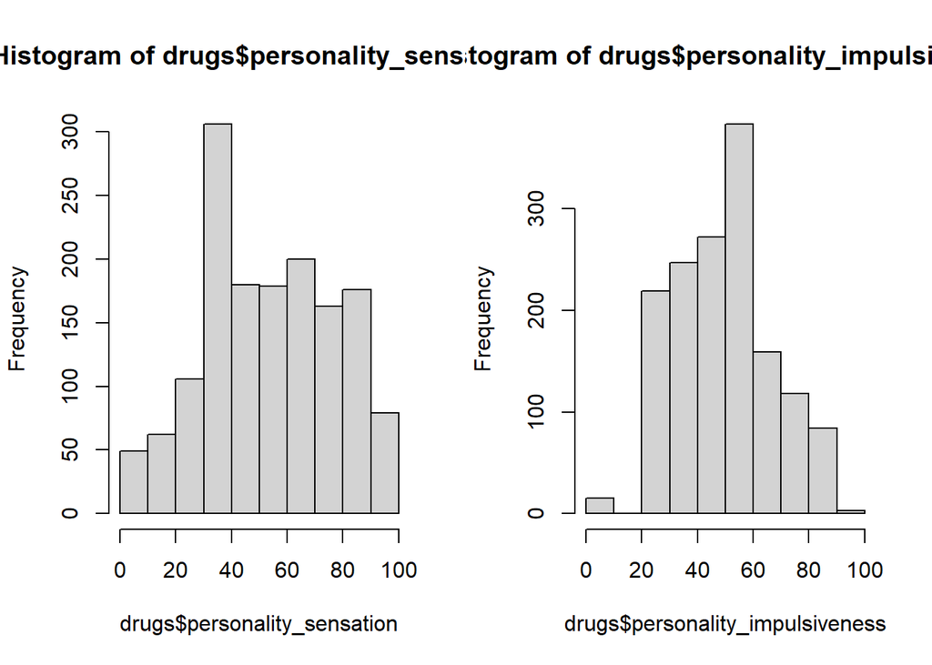

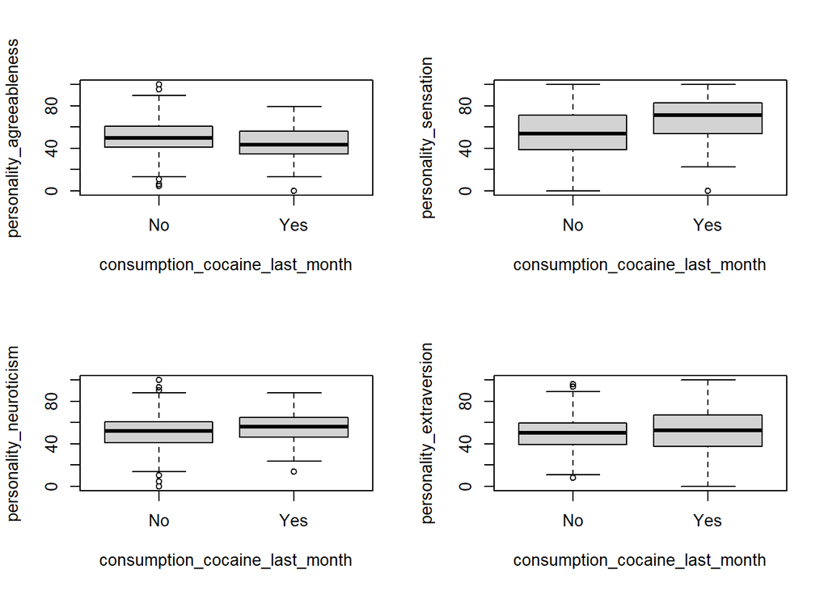

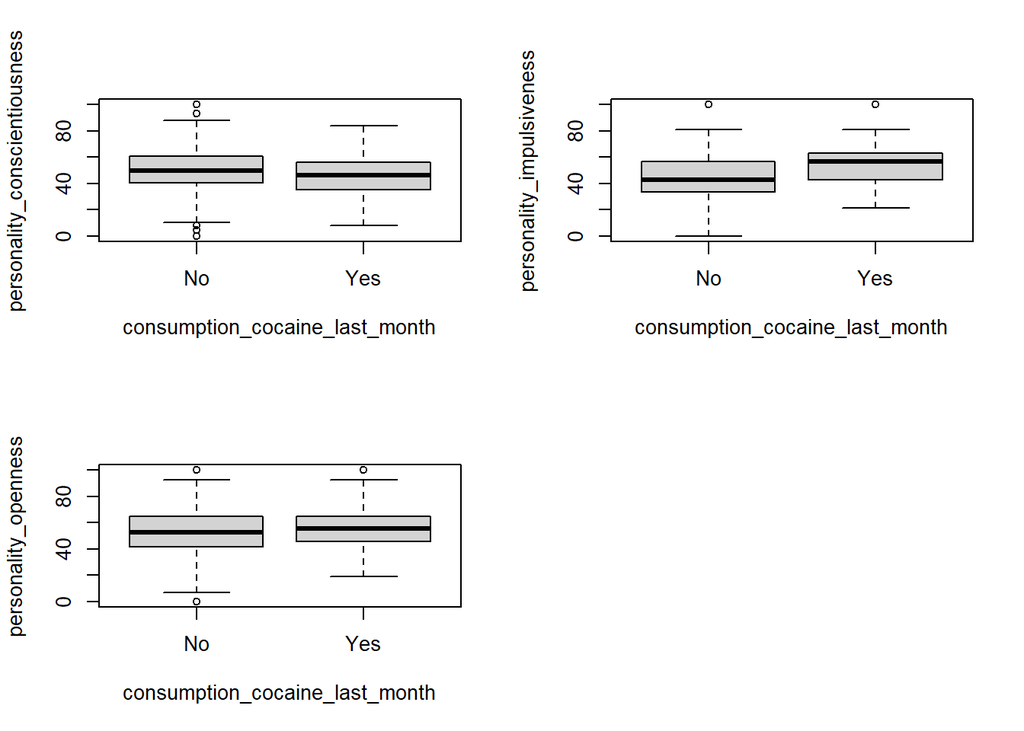

To reduce possible overfitting of the model, we decided to transform numerical variables related to personality. The reason of that is the fact those personality traits are generally hard to measure and the fact that somebody got let’s say 42.5 and not 47.9 might not be statistically important. Therefore we decided to transform those variables based cut-off points: under 35 point would indicate that this personality trait is weak, between 35 and 65 points that character trait is neutral, and above 65 that it is strong.  
We also tried out other options, such as transforming those variables to 2 or 5 levels based on quantiles or transforming to different number of levels based on hard cut off points. However, we found out that these cut-off points give the best results in terms of ROC, Sensibility, Accuracy and Kappa.

### Balancing sample

```r
table(drugs$consumption_cocaine_last_month)
```

```
##
##   No  Yes
## 1373  127
```

This is why we decided to balance the sample. We compared 3 different methods: weighning observations, upsampling and SMOTE.

For model validation we are splitting the data into train and test samples: 1100 observations for training and 400 for test. Additionaly, we are using cross-validation on the training sample. Here in each case we are using 5-fold cross-validation repeated 3 times.

```r
set.seed(987654321)
drugs_which_training <- createDataPartition(drugs$consumption_cocaine_last_month,
                                            p = 1099/1500,
                                            list = FALSE)

drugs_train <- drugs[c(drugs_which_training),]
drugs_test <- drugs[-c(drugs_which_training),]

ctrl_cv5 <- trainControl(method = "repeatedcv",
                         number = 5,
                         classProbs = TRUE,
                         summaryFunction = mySummary,
                         repeats = 3)
```

#### Basic model

```r
set.seed(0)
drugs_logit_train
```

```
## Generalized Linear Model
##
## 1100 samples
##   17 predictor
##    2 classes: 'No', 'Yes'
##
## No pre-processing
## Resampling: Cross-Validated (5 fold, repeated 3 times)
## Summary of sample sizes: 880, 879, 880, 880, 881, 880, ...
## Resampling results:
##
##   ROC        Accuracy   Kappa      Sensitivity  Specificity  Pos Pred Value
##   0.7866353  0.9027281  0.1455609  0.9748157    0.1315789    0.9231466
##   Neg Pred Value  Precision  Recall     F1         Balanced Accuracy
##   0.3497306       0.9231466  0.9748157  0.9482342  0.5531973
```

#### Weightning observations

```r
set.seed(987654321)

drugs_logit_train_weighted <-
  train(consumption_cocaine_last_month ~ .,
        data = drugs_train,
        method = "glm",
        family = "binomial",
        trControl = ctrl_cv5,
        weights = myWeights)

drugs_logit_train_weighted
```

```
## Generalized Linear Model
##
## 1100 samples
##   17 predictor
##    2 classes: 'No', 'Yes'
##
## No pre-processing
## Resampling: Cross-Validated (5 fold, repeated 3 times)
## Summary of sample sizes: 880, 880, 880, 880, 880, 880, ...
## Resampling results:
##
##   ROC        Accuracy   Kappa      Sensitivity  Specificity  Pos Pred Value
##   0.7692669  0.7545503  0.1992256  0.7667323    0.6243665    0.9564357
##   Neg Pred Value  Precision  Recall     F1         Balanced Accuracy
##   0.2003792       0.9564357  0.7667323  0.8507507  0.6955494
```

#### Upsampling

We use upsampling (and not downsampling) because the number of observations is not large.

```r
ctrl_cv5$sampling <- "up"

set.seed(987654321)

drugs_logit_train_up <-
  train(consumption_cocaine_last_month ~ .,
        data = drugs_train,
        method = "glm",
        family = "binomial",
        trControl = ctrl_cv5
        )

drugs_logit_train_up
```

```
## Generalized Linear Model
##
## 1100 samples
##   17 predictor
##    2 classes: 'No', 'Yes'
##
## No pre-processing
## Resampling: Cross-Validated (5 fold, repeated 3 times)
## Summary of sample sizes: 880, 880, 880, 880, 880, 880, ...
## Addtional sampling using up-sampling
##
## Resampling results:
##
##   ROC        Accuracy   Kappa      Sensitivity  Specificity  Pos Pred Value
##   0.7649221  0.7548548  0.1872492  0.7700409    0.5922027    0.9531373
##   Neg Pred Value  Precision  Recall     F1         Balanced Accuracy
##   0.1941904       0.9531373  0.7700409  0.8514112  0.6811218
```

#### SMOTE model

```r
ctrl_cv5$sampling <- "smote"

set.seed(987654321)

drugs_logit_train_smote <-
  train(consumption_cocaine_last_month ~ .,
        data = drugs_train,
        method = "glm",
        family = "binomial",
        trControl = ctrl_cv5
  )

drugs_logit_train_smote
```

```
## Generalized Linear Model
##
## 1100 samples
##   17 predictor
##    2 classes: 'No', 'Yes'
##
## No pre-processing
## Resampling: Cross-Validated (5 fold, repeated 3 times)
## Summary of sample sizes: 880, 880, 880, 880, 880, 880, ...
## Addtional sampling using SMOTE
##
## Resampling results:
##
##   ROC        Accuracy   Kappa      Sensitivity  Specificity  Pos Pred Value
##   0.7675769  0.7751564  0.2113432  0.792245     0.5923977    0.9543229
##   Neg Pred Value  Precision  Recall    F1         Balanced Accuracy
##   0.2114736       0.9543229  0.792245  0.8653423  0.6923214
```

#### Comparison

```
##                            Accuracy Sensitivity Specificity Pos Pred Value
## drugs_logit_train           0.92182     0.21277     0.98807        0.62500
## drugs_logit_train_smote     0.79273     0.82979     0.78926        0.26897
## drugs_logit_train_up        0.77818     0.82979     0.77336        0.25490
## drugs_logit_train_weighted  0.77636     0.85106     0.76938        0.25641
##                            Neg Pred Value      F1 Balanced Accuracy
## drugs_logit_train                 0.93071 0.31746           0.60042
## drugs_logit_train_smote           0.98025 0.40625           0.80953
## drugs_logit_train_up              0.97985 0.39000           0.80157
## drugs_logit_train_weighted        0.98223 0.39409           0.81022
```

### Logit and probit

Logit and probit are two main regression models for classification.

Let’s focus on the logistic regression model we estimated with upsampling.

```r
set.seed(987654321)
drugs_logit_train_final <-
  train(consumption_cocaine_last_month ~ .,
        data = drugs_train,
        method = "glm",
        family = "binomial",
        trControl = ctrl_cv5_logit)
```

```r
summary(drugs_logit_train_final)
```

```
##
## Call:
## NULL
##
## Deviance Residuals:
##      Min        1Q    Median        3Q       Max
## -2.94524  -0.53185   0.06398   0.74741   2.31928
##
## Coefficients:
##                                  Estimate Std. Error z value Pr(>|z|)
## (Intercept)                    -1.176e+01  4.132e+02  -0.028 0.977287
## age.L                          -1.361e-01  2.927e-01  -0.465 0.642032
## age.Q                           7.992e-01  2.579e-01   3.099 0.001944 **
## age.C                          -2.762e-01  2.055e-01  -1.344 0.179099
## `age^4`                        -2.968e-01  1.949e-01  -1.523 0.127861
## gender.L                        1.910e-02  1.055e-01   0.181 0.856268
## education.L                     6.319e-01  1.817e-01   3.478 0.000505 ***
## education.Q                     4.154e-01  1.711e-01   2.428 0.015182 *
## education.C                    -9.368e-02  1.383e-01  -0.677 0.498161
## `education^4`                   2.641e-01  1.767e-01   1.494 0.135103
## countryOther                   -4.418e-02  1.844e-01  -0.240 0.810695
## countryUSA                     -3.391e-01  1.831e-01  -1.852 0.064066 .
## personality_neuroticism1        8.766e-01  2.396e-01   3.659 0.000253 ***
## personality_neuroticism2        1.580e+00  2.928e-01   5.395 6.87e-08 ***
## personality_extraversion1      -6.603e-01  1.939e-01  -3.406 0.000660 ***
## personality_extraversion2       1.262e+00  2.450e-01   5.149 2.61e-07 ***
## personality_openness1           3.038e-01  2.480e-01   1.225 0.220624
## personality_openness2          -6.682e-01  2.838e-01  -2.354 0.018548 *
## personality_agreeableness1     -8.926e-02  1.702e-01  -0.524 0.599984
## personality_agreeableness2     -5.587e-01  2.495e-01  -2.239 0.025160 *
## personality_conscientiousness1  3.582e-02  1.918e-01   0.187 0.851894
## personality_conscientiousness2 -3.839e-02  2.745e-01  -0.140 0.888750
## personality_impulsiveness1     -2.294e-01  1.831e-01  -1.252 0.210401
## personality_impulsiveness2     -5.209e-01  2.501e-01  -2.083 0.037296 *
## personality_sensation1          6.633e-01  2.365e-01   2.805 0.005030 **
## personality_sensation2          1.078e+00  2.637e-01   4.086 4.39e-05 ***
## consumption_alcohol.L           1.094e+01  3.349e+02   0.033 0.973933
## consumption_alcohol.Q          -8.552e+00  2.831e+02  -0.030 0.975898
## consumption_alcohol.C           5.195e+00  1.675e+02   0.031 0.975252
## `consumption_alcohol^4`        -1.627e+00  6.330e+01  -0.026 0.979500
```

[output cut: 15 more lines]

```
## `consumption_mushrooms^4`      -5.769e-01  1.602e-01  -3.602 0.000316 ***
## consumption_nicotine.L          1.308e-01  1.902e-01   0.688 0.491687
## consumption_nicotine.Q          9.588e-01  1.973e-01   4.860 1.17e-06 ***
## consumption_nicotine.C          4.818e-01  2.539e-01   1.897 0.057789 .
## `consumption_nicotine^4`        5.861e-04  2.450e-01   0.002 0.998091
## ---
## Signif. codes:  0 '***' 0.001 '**' 0.01 '*' 0.05 '.' 0.1 ' ' 1
##
## (Dispersion parameter for binomial family taken to be 1)
##
##     Null deviance: 2789.2  on 2011  degrees of freedom
## Residual deviance: 1694.4  on 1962  degrees of freedom
## AIC: 1794.4
##
## Number of Fisher Scoring iterations: 16
```

```r
drugs_logit_train_final
```

```
## Generalized Linear Model
##
## 1100 samples
##   17 predictor
##    2 classes: 'No', 'Yes'
##
## No pre-processing
## Resampling: Cross-Validated (5 fold, repeated 3 times)
## Summary of sample sizes: 880, 880, 880, 880, 880, 880, ...
## Addtional sampling using up-sampling
##
## Resampling results:
##
##   ROC        Accuracy   Kappa      Sensitivity  Specificity  Pos Pred Value
##   0.7649221  0.7548548  0.1872492  0.7700409    0.5922027    0.9531373
##   Neg Pred Value  Precision  Recall     F1         Balanced Accuracy
##   0.1941904       0.9531373  0.7700409  0.8514112  0.6811218
```

We also tried the probit model.

```r
set.seed(987654321)
drugs_probit_train_final <-
  train(consumption_cocaine_last_month ~ .,
        data = drugs_train,
        method = "glm",
        family = binomial(link = "probit"),
        trControl = ctrl_cv5_logit)
drugs_probit_train_final
```

```
## Generalized Linear Model
##
## 1100 samples
##   17 predictor
##    2 classes: 'No', 'Yes'
##
## No pre-processing
## Resampling: Cross-Validated (5 fold, repeated 3 times)
## Summary of sample sizes: 880, 880, 880, 880, 880, 880, ...
## Addtional sampling using up-sampling
##
## Resampling results:
##
##   ROC        Accuracy   Kappa      Sensitivity  Specificity  Pos Pred Value
##   0.7690297  0.7575834  0.1901781  0.773026     0.5923977    0.9532956
##   Neg Pred Value  Precision  Recall    F1         Balanced Accuracy
##   0.1961473       0.9532956  0.773026  0.8533508  0.6827118
```

```r
summary(drugs_probit_train_final)
```

```
##
## Call:
## NULL
##
## Deviance Residuals:
##      Min        1Q    Median        3Q       Max
## -3.05687  -0.54385   0.04013   0.78115   2.18202
##
## Coefficients:
##                                  Estimate Std. Error z value Pr(>|z|)
## (Intercept)                     -4.249927  62.133673  -0.068 0.945467
## age.L                           -0.086482   0.165614  -0.522 0.601536
## age.Q                            0.426763   0.145699   2.929 0.003400 **
## age.C                           -0.159071   0.115983  -1.371 0.170220
## `age^4`                         -0.178757   0.108993  -1.640 0.100991
## gender.L                         0.005783   0.059904   0.097 0.923099
## education.L                      0.377106   0.102717   3.671 0.000241 ***
## education.Q                      0.227170   0.096776   2.347 0.018906 *
## education.C                     -0.035900   0.079096  -0.454 0.649910
## `education^4`                    0.129104   0.099384   1.299 0.193931
## countryOther                    -0.020531   0.105680  -0.194 0.845957
## countryUSA                      -0.156024   0.104649  -1.491 0.135979
## personality_neuroticism1         0.439625   0.133430   3.295 0.000985 ***
## personality_neuroticism2         0.820462   0.163310   5.024 5.06e-07 ***
## personality_extraversion1       -0.372168   0.110500  -3.368 0.000757 ***
## personality_extraversion2        0.670509   0.138808   4.830 1.36e-06 ***
## personality_openness1            0.155382   0.137412   1.131 0.258149
## personality_openness2           -0.336985   0.157198  -2.144 0.032058 *
## personality_agreeableness1      -0.090322   0.096179  -0.939 0.347674
## personality_agreeableness2      -0.357564   0.141806  -2.522 0.011685 *
## personality_conscientiousness1   0.042139   0.109862   0.384 0.701300
## personality_conscientiousness2  -0.021321   0.157165  -0.136 0.892092
## personality_impulsiveness1      -0.147097   0.104395  -1.409 0.158825
## personality_impulsiveness2      -0.317530   0.141296  -2.247 0.024623 *
## personality_sensation1           0.364865   0.132618   2.751 0.005937 **
## personality_sensation2           0.622787   0.148659   4.189 2.80e-05 ***
## consumption_alcohol.L            3.860877  48.433106   0.080 0.936463
## consumption_alcohol.Q           -2.851884  40.933519  -0.070 0.944455
## consumption_alcohol.C            1.754482  24.217075   0.072 0.942245
## `consumption_alcohol^4`         -0.478976   9.154177  -0.052 0.958271
```

[output cut: 15 more lines]

```
## `consumption_mushrooms^4`       -0.319143   0.091166  -3.501 0.000464 ***
## consumption_nicotine.L           0.054278   0.108359   0.501 0.616435
## consumption_nicotine.Q           0.576960   0.112885   5.111 3.20e-07 ***
## consumption_nicotine.C           0.257835   0.145466   1.772 0.076317 .
## `consumption_nicotine^4`        -0.006728   0.141533  -0.048 0.962088
## ---
## Signif. codes:  0 '***' 0.001 '**' 0.01 '*' 0.05 '.' 0.1 ' ' 1
##
## (Dispersion parameter for binomial family taken to be 1)
##
##     Null deviance: 2789.2  on 2011  degrees of freedom
## Residual deviance: 1700.3  on 1962  degrees of freedom
## AIC: 1800.3
##
## Number of Fisher Scoring iterations: 15
```

```r
drugs_probit_train_final
```

```
## Generalized Linear Model
##
## 1100 samples
##   17 predictor
##    2 classes: 'No', 'Yes'
##
## No pre-processing
## Resampling: Cross-Validated (5 fold, repeated 3 times)
## Summary of sample sizes: 880, 880, 880, 880, 880, 880, ...
## Addtional sampling using up-sampling
##
## Resampling results:
##
##   ROC        Accuracy   Kappa      Sensitivity  Specificity  Pos Pred Value
##   0.7690297  0.7575834  0.1901781  0.773026     0.5923977    0.9532956
##   Neg Pred Value  Precision  Recall    F1         Balanced Accuracy
##   0.1961473       0.9532956  0.773026  0.8533508  0.6827118
```

### KNN

KNN (k nearest neighbours) is a supervised learning method in which (in case of classification) the object is being assigned to the class most common among its k nearest neighbors. Here we try out different values of k from 1 to 40 by 2 and select the best one.

```r
ctrl_cv5_knn <- trainControl(method = "repeatedcv",
                         number = 5,
                         classProbs = TRUE,
                         summaryFunction = mySummary,
                         repeats = 3)
ctrl_cv5_knn$sampling <- "up"

different_k = data.frame(k = seq(1, 40, 2) )

set.seed(987654321)
drugs_knn_train <-
  train(consumption_cocaine_last_month ~ .,
        drugs_train,
        method = "knn",
        metric = "ROC",
        trControl = ctrl_cv5_knn,
        tuneGrid = different_k,
        preProcess = c("range"))

drugs_knn_train
```

```
## k-Nearest Neighbors
##
## 1100 samples
##   17 predictor
##    2 classes: 'No', 'Yes'
##
## Pre-processing: re-scaling to [0, 1] (49)
## Resampling: Cross-Validated (5 fold, repeated 3 times)
## Summary of sample sizes: 880, 880, 880, 880, 880, 880, ...
## Addtional sampling using up-sampling prior to pre-processing
##
## Resampling results across tuning parameters:
##
##   k   ROC        Accuracy   Kappa      Sensitivity  Specificity  Pos Pred Value
##    1  0.5703698  0.8654583  0.1341816  0.9264470    0.2138402    0.9265859
##    3  0.6463404  0.7681757  0.1557148  0.7952219    0.4797271    0.9424507
##    5  0.6807151  0.7121081  0.1567472  0.7206656    0.6214425    0.9532813
##    7  0.7055373  0.6636107  0.1494219  0.6583584    0.7200780    0.9621806
##    9  0.7184625  0.6260445  0.1369119  0.6129698    0.7662768    0.9659056
##   11  0.7264967  0.6169425  0.1441861  0.5987127    0.8122807    0.9719884
##   13  0.7444134  0.6087744  0.1364679  0.5904422    0.8048733    0.9703130
##   15  0.7587248  0.6145252  0.1391743  0.5970773    0.8017544    0.9703485
##   17  0.7589269  0.6245432  0.1459466  0.6080078    0.8019493    0.9705770
##   19  0.7550991  0.6299728  0.1396772  0.6172684    0.7660819    0.9659880
##   21  0.7687377  0.6327153  0.1492589  0.6179416    0.7910331    0.9695232
##   23  0.7678611  0.6403035  0.1486868  0.6278837    0.7729045    0.9674854
##   25  0.7707604  0.6454523  0.1577593  0.6318621    0.7912281    0.9701506
##   27  0.7790735  0.6530281  0.1640642  0.6398059    0.7945419    0.9710619
##   29  0.7838523  0.6469646  0.1599379  0.6331971    0.7943470    0.9706312
##   31  0.7888094  0.6351162  0.1554934  0.6192519    0.8050682    0.9712806
##   33  0.7851397  0.6484729  0.1604511  0.6351674    0.7908382    0.9701943
##   35  0.7933150  0.6448379  0.1682167  0.6275487    0.8296296    0.9753373
##   37  0.7932339  0.6454371  0.1659649  0.6292071    0.8192982    0.9738624
##   39  0.7966067  0.6418090  0.1623538  0.6255455    0.8155945    0.9731739
##   Neg Pred Value  Precision  Recall     F1         Balanced Accuracy
##   0.2042027       0.9265859  0.9264470  0.9264328  0.5701436
##   0.1794914       0.9424507  0.7952219  0.8623090  0.6374745
##   0.1724237       0.9532813  0.7206656  0.8204216  0.6710541
##   0.1646537       0.9621806  0.6583584  0.7811457  0.6892182
##   0.1562815       0.9659056  0.6129698  0.7493779  0.6896233
##   0.1595738       0.9719884  0.5987127  0.7399765  0.7054967
##   0.1552377       0.9703130  0.5904422  0.7337067  0.6976577
##   0.1568573       0.9703485  0.5970773  0.7385131  0.6994159
##   0.1606652       0.9705770  0.6080078  0.7472273  0.7049786
##   0.1578498       0.9659880  0.6172684  0.7526943  0.6916752
##   0.1628952       0.9695232  0.6179416  0.7539878  0.7044874
##   0.1628498       0.9674854  0.6278837  0.7610671  0.7003941
##   0.1677245       0.9701506  0.6318621  0.7647043  0.7115451
##   0.1712990       0.9710619  0.6398059  0.7707928  0.7171739
##   0.1689206       0.9706312  0.6331971  0.7659147  0.7137720
##   0.1662030       0.9712806  0.6192519  0.7557482  0.7121601
##   0.1693483       0.9701943  0.6351674  0.7670561  0.7130028
##   0.1728225       0.9753373  0.6275487  0.7633099  0.7285892
##   0.1718020       0.9738624  0.6292071  0.7640173  0.7242527
##   0.1697981       0.9731739  0.6255455  0.7610922  0.7205700
##
## ROC was used to select the optimal model using the largest value.
## The final value used for the model was k = 39.
```

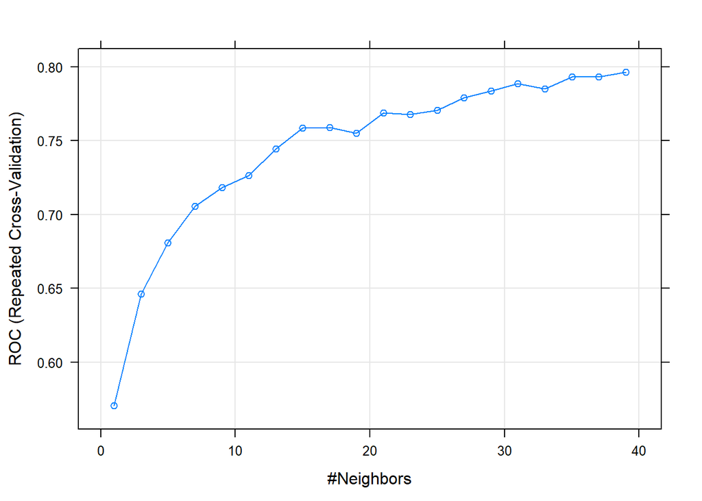

```r
plot(drugs_knn_train)
```

Taking ROC into account, the best model is with k = 39. It has also relatively high Balanced Accuracy.

### SVM

SVM (support-vector machine) is a supervised learning model which maps training examples to points in space so as to maximise the width of the gap between the two categories.

Here we are running SVM with radial basis kernel (gaussian).

```r
ctrl_cv5_svm <- trainControl(method = "cv",
                         number = 5,
                         classProbs = TRUE)
ctrl_cv5_svm$sampling <- "up"

parametersC_sigma <-
  expand.grid(C = c(0.01, 0.1, 1, 5, 10),
              sigma = c(0.01, 0.1, 1, 5, 10))
set.seed(987654321)
drugs_svm_train <- train(consumption_cocaine_last_month ~ .,
                           data = drugs_train,
                           method = "svmRadial",
                           tuneGrid = parametersC_sigma,
                           trControl = ctrl_cv5_svm)
drugs_svm_train
```

```
## Support Vector Machines with Radial Basis Function Kernel
##
## 1100 samples
##   17 predictor
##    2 classes: 'No', 'Yes'
##
## No pre-processing
## Resampling: Cross-Validated (5 fold)
## Summary of sample sizes: 880, 880, 880, 880, 880
## Addtional sampling using up-sampling
##
## Resampling results across tuning parameters:
##
##   C      sigma  Accuracy   Kappa
##    0.01   0.01  0.6945455   0.20877483
##    0.01   0.10  0.9172727   0.05381924
##    0.01   1.00  0.9145455   0.00000000
##    0.01   5.00  0.9145455   0.00000000
##    0.01  10.00  0.9145455   0.00000000
##    0.10   0.01  0.7727273   0.23744336
##    0.10   0.10  0.9145455   0.07716911
##    0.10   1.00  0.9145455   0.00000000
##    0.10   5.00  0.9145455   0.00000000
##    0.10  10.00  0.9145455   0.00000000
##    1.00   0.01  0.8754545   0.21985513
##    1.00   0.10  0.9136364  -0.00174232
##    1.00   1.00  0.9145455   0.00000000
##    1.00   5.00  0.9145455   0.00000000
##    1.00  10.00  0.9145455   0.00000000
##    5.00   0.01  0.9109091   0.10884639
##    5.00   0.10  0.9145455   0.00000000
##    5.00   1.00  0.9145455   0.00000000
##    5.00   5.00  0.9145455   0.00000000
##    5.00  10.00  0.9145455   0.00000000
##   10.00   0.01  0.9145455   0.10678220
##   10.00   0.10  0.9145455   0.00000000
##   10.00   1.00  0.9145455   0.00000000
##   10.00   5.00  0.9145455   0.00000000
##   10.00  10.00  0.9145455   0.00000000
##
## Accuracy was used to select the optimal model using the largest value.
## The final values used for the model were sigma = 0.1 and C = 0.01.
```

We wanted to also try out polynomial kernel.

```r
svm_parametersPoly <- expand.grid(C = c(0.01, 1),
                                  degree = 2:5,
                                  scale = c(1,10))
set.seed(987654321)
drugs_svm_train2 <- train(consumption_cocaine_last_month ~ .,
                         data = drugs_train,
                         method = "svmPoly",
                         tuneGrid = svm_parametersPoly,
                         trControl = ctrl_cv5_svm)
drugs_svm_train2
```

```
## Support Vector Machines with Polynomial Kernel
##
## 1100 samples
##   17 predictor
##    2 classes: 'No', 'Yes'
##
## No pre-processing
## Resampling: Cross-Validated (5 fold)
## Summary of sample sizes: 880, 880, 880, 880, 880
## Addtional sampling using up-sampling
##
## Resampling results across tuning parameters:
##
##   C     degree  scale  Accuracy   Kappa
##   0.01  2        1     0.9045455  0.11154304
##   0.01  2       10     0.9063636  0.11639987
##   0.01  3        1     0.9163636  0.05288495
##   0.01  3       10     0.9154545  0.05114263
##   0.01  4        1     0.9154545  0.05114263
##   0.01  4       10     0.9154545  0.06668097
##   0.01  5        1     0.9145455  0.03337918
##   0.01  5       10     0.9145455  0.03337918
##   1.00  2        1     0.9054545  0.10163423
##   1.00  2       10     0.9054545  0.10025065
##   1.00  3        1     0.9163636  0.05288495
##   1.00  3       10     0.9163636  0.05288495
##   1.00  4        1     0.9154545  0.05114263
##   1.00  4       10     0.9154545  0.05114263
##   1.00  5        1     0.9145455  0.03337918
##   1.00  5       10     0.9145455  0.03337918
##
## Accuracy was used to select the optimal model using the largest value.
## The final values used for the model were degree = 3, scale = 1 and C = 0.01.
```

Here Accuracy is similiarly high as with the gaussian kernel but all Kappa are quite low. We would probably want to reject those cases. Therefore, our final SVM model is with gaussian kernel with parameters C = 1 and sigma = 0.01.

### Model comparison and selection

To select the best model, we compared performance of logit, probit, KNN and SVM models on training, test and general (combined training and test) samples using different performance measures.

```
##              Accuracy Sensitivity Specificity Pos Pred Value Neg Pred Value
## logit_train   0.77818     0.82979     0.77336        0.25490        0.97985
## probit_train  0.78000     0.81915     0.77634        0.25497        0.97870
## knn_train     0.64636     0.92553     0.62028        0.18550        0.98891
## svm_train     0.94455     0.97872     0.94135        0.60927        0.99789
## logit_test    0.76000     0.66667     0.76839        0.20561        0.96246
## probit_test   0.76000     0.66667     0.76839        0.20561        0.96246
## knn_test      0.65250     0.87879     0.63215        0.17683        0.98305
## svm_test      0.86000     0.30303     0.91008        0.23256        0.93557
## logit_all     0.77333     0.78740     0.77203        0.24213        0.97516
## probit_all    0.77467     0.77953     0.77422        0.24205        0.97434
## knn_all       0.64600     0.91339     0.62127        0.18239        0.98727
## svm_all       0.92200     0.80315     0.93299        0.52577        0.98086
##                   F1 BALANCED ACCURACY
## logit_train  0.39000           0.80157
## probit_train 0.38889           0.79775
## knn_train    0.30906           0.77291
## svm_train    0.75102           0.96004
## logit_test   0.31429           0.71753
## probit_test  0.31429           0.71753
## knn_test     0.29442           0.75547
## svm_test     0.26316           0.60656
## logit_all    0.37037           0.77972
## probit_all   0.36940           0.77687
## knn_all      0.30406           0.76733
## svm_all      0.63551           0.86807
```

###### SVM

Overall, we found out that SVM quality heavily depends on the parameters which are hard to specify (due to, among others, bigger computational power needed to estimate different combinations of parameters). SVM model validation on training and test samples is drastically different and much worse on the test sample. Therefore we do not consider this algorithm.

###### Logit and Probit

Logit performance is almost identical to the Probit one. However, logit performs slightly better on the training sample in terms of balanced accuracy (which will be eveluated) so out of those two we would choose Logit. Therefore, the choice boils down to Logit VS KNN.

###### Logit VS KNN

The choice of Logit vs KNN is hard as in different cases one performs better than the other. For example, KNN performs worse than Logit on the training sample in terms of Balanced Accuracy, but better on the test sample. As test sample performance should be more reliable in terms of simulating evalueation data, we would like to go with KNN as our final model.

### Data preparation

#### General

In the first step, we loaded the data. Then they were checked if any missing observations are present within the data. We also analyzed the structure and type of the variables.

```r
traffic_train=read.csv(file="traffic_train.csv",sep=",",header=TRUE)
traffic_test=read.csv(file="traffic_test.csv",sep=",",header=TRUE)

head(traffic_train,2)
```

```
##             date_time weather_general weather_detailed clouds_coverage_pct
## 1 2014-10-01 00:00:00           Clear     sky is clear                   1
## 2 2014-10-01 01:00:00           Clear     sky is clear                   1
##   temperature rain_mm snow_mm traffic
## 1        11.5       0       0     508
## 2        10.3       0       0     323
```

```r
colSums(is.na(traffic_train)) %>% sort()
```

```
##           date_time     weather_general    weather_detailed clouds_coverage_pct
##                   0                   0                   0                   0
##         temperature             rain_mm             snow_mm             traffic
##                   0                   0                   0                   0
```

There were no missing data.

The first column - the date of observation with an accuracy of an hour was converted to the datetime data type.

```r
traffic_train$DateT <- as.POSIXct(traffic_train$date_time, format="%Y-%m-%d %H:%M:%S", tz="GMT")
traffic_test$DateT <- as.POSIXct(traffic_test$date_time, format="%Y-%m-%d %H:%M:%S", tz="GMT")
```

The data showed a very large variability in traffic due to daily fluctuations.

[interactive chart not shown]

Instead of using the index column, we created features describing each time characteristic: hour, month, year, yearweek (which might represent information about holidays), weekday, weekend and date.

```r
traffic_train$time <- format(traffic_train$DateT, format = "%H")
traffic_train$month <- format(traffic_train$DateT, format = "%m")
traffic_train$year <- format(traffic_train$DateT, format = "%Y")
traffic_train$yearweek <- format(traffic_train$DateT, format = "%W")
traffic_train$weekday <- format(traffic_train$DateT, format = "%w")
traffic_train$weekend <- ifelse((traffic_train$weekday == 0)+(traffic_train$weekday == 6),"weekend","weekday")
traffic_train$date <- format(traffic_train$DateT, format = "%Y-%m-%d")

traffic_test$time <- format(traffic_test$DateT, format = "%H")
traffic_test$month <- format(traffic_test$DateT, format = "%m")
traffic_test$year <- format(traffic_test$DateT, format = "%Y")
traffic_test$yearweek <- format(traffic_test$DateT, format = "%W")
traffic_test$weekday <- format(traffic_test$DateT, format = "%w")
traffic_test$weekend <- ifelse((traffic_test$weekday == 0)+(traffic_test$weekday == 6),"weekend","weekday")
traffic_test$date <- format(traffic_test$DateT, format = "%Y-%m-%d")
```

Our train dataset covers the period between 2014-10-01 and 2018-12-31, consists of 1223 days, giving 29701 observations total.

```
## [1] 1223
```

```
## [1] "2014-10-01" "2018-12-31"
```

```
## [1] 29701
```

The weather conditions are described by two variables: weather_general and weather_detailed. The detailed feature includes 37 levels which are very similar to the general variable levels. In addition, some of the levels are very small, which could affect the results bias. For this reason, we have decided not to use the weather_detailed characteristic, which should also reduce possible overfitting of the model.

```r
table(traffic_train$weather_detailed)
```

```
##
##                       broken clouds                             drizzle
##                                3130                                 337
##                          few clouds                                 fog
##                                1499                                 481
##                       freezing rain                                haze
##                                   2                                 743
##             heavy intensity drizzle                heavy intensity rain
##                                  31                                 287
##                          heavy snow             light intensity drizzle
##                                 581                                 551
##         light intensity shower rain                          light rain
##                                   8                                2248
##                 light rain and snow                   light shower snow
##                                   4                                   4
##                          light snow                                mist
##                                1046                                3491
##                       moderate rain                     overcast clouds
##                                 966                                3491
##               proximity shower rain              proximity thunderstorm
##                                  31                                 311
## proximity thunderstorm with drizzle    proximity thunderstorm with rain
##                                   8                                  19
##                    scattered clouds                      shower drizzle
##                                2044                                   1
##                         shower snow                        sky is clear
##                                   1                                8030
##                               sleet                               smoke
##                                   1                                  17
##                                snow                             squalls
##                                 157                                   4
##                        thunderstorm           thunderstorm with drizzle
##                                  58                                   2
##        thunderstorm with heavy rain     thunderstorm with light drizzle
##                                  42                                   2
##        thunderstorm with light rain              thunderstorm with rain
##                                  32                                  23
##                     very heavy rain
##                                  18
```

All variables which were stored as characters were converted to factors.

```r
traffic_train$weather_general <- as.factor(traffic_train$weather_general)
traffic_test$weather_general <- as.factor(traffic_test$weather_general)

traffic_train$weekend <- as.factor(traffic_train$weekend)
traffic_train$yearweek <- as.factor(traffic_train$yearweek)
traffic_train$weekday <- as.factor(traffic_train$weekday)
traffic_train$month <- as.factor(traffic_train$month)
traffic_train$time <- as.factor(traffic_train$time)

traffic_test$weekend <- as.factor(traffic_test$weekend)
traffic_test$yearweek <- as.factor(traffic_test$yearweek)
traffic_test$weekday <- as.factor(traffic_test$weekday)
traffic_test$month <- as.factor(traffic_test$month)
traffic_test$time <- as.factor(traffic_test$time)
```

We also changed the type of the variable Year to numeric.

```r
traffic_train$year <- as.numeric(traffic_train$year)
traffic_test$year <- as.numeric(traffic_test$year)
```

```r
traffic_train_train <- traffic_train[traffic_train$year <= 2017,]
traffic_train_test <- traffic_train[traffic_train$year >= 2018,]
```

#### Numeric variables

We plotted the numeric variables’ distributions using histograms and noticed that their distributions were highly skewed in most cases. Moreover the traffic distribution has multiple peaks, which makes even harder to model.

```r
summary(traffic_train_train$traffic)
```

```
##    Min. 1st Qu.  Median    Mean 3rd Qu.    Max.
##       0    1174    3327    3255    4978    7217
```

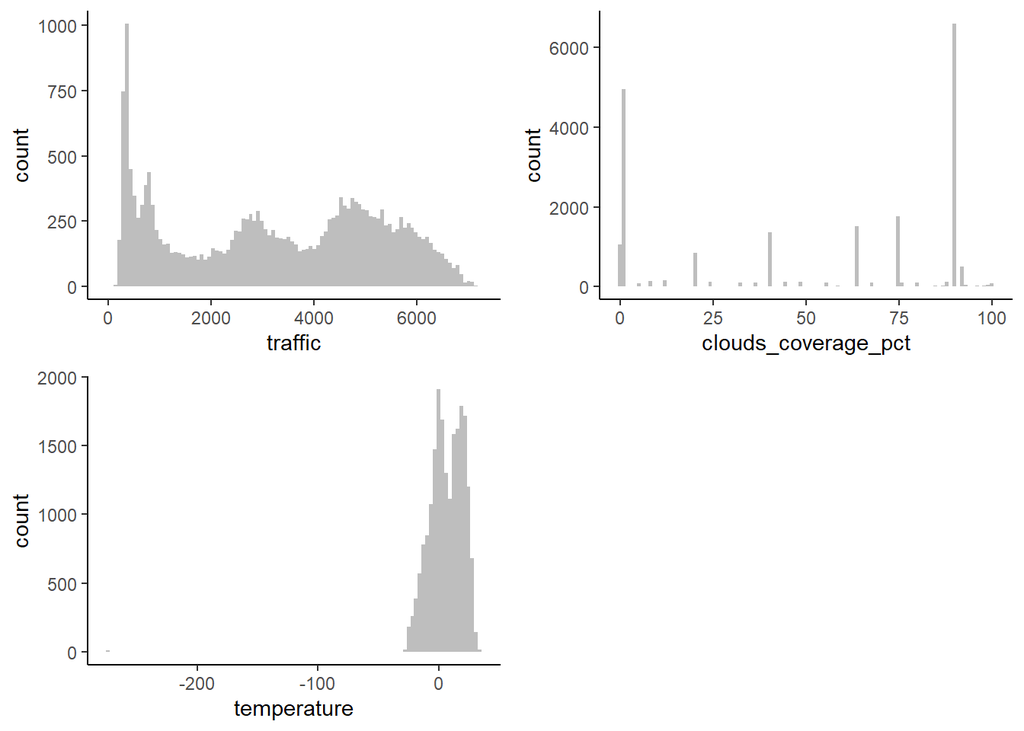

Rainfall> 0 mm was observed only in 11% of our observations, and snowfall happened even less frequently, only in 0.2% of our observations.

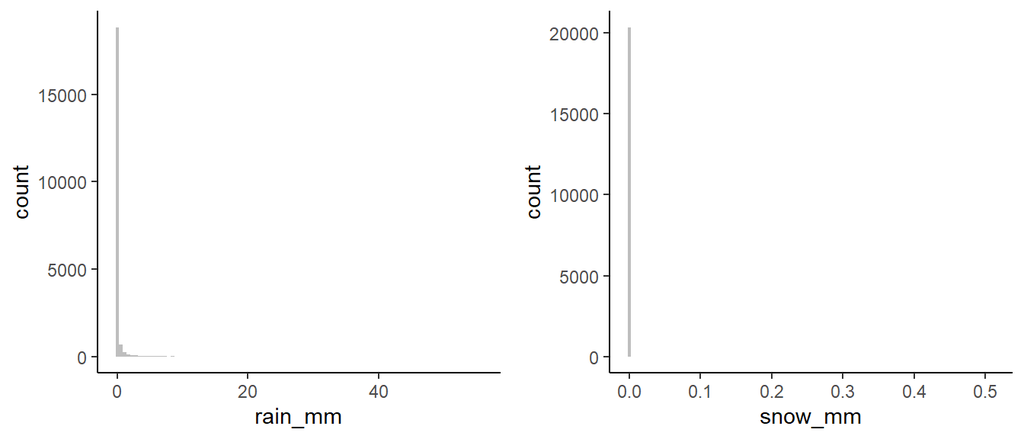

#### Ordinal and categorical variables

Most of the observations represent a good weather. However, we’ll combine the similar events: “Smoke” and “Haze” levels and “Squall” and “Thunderstorm”, which are usually very extreme weather events.

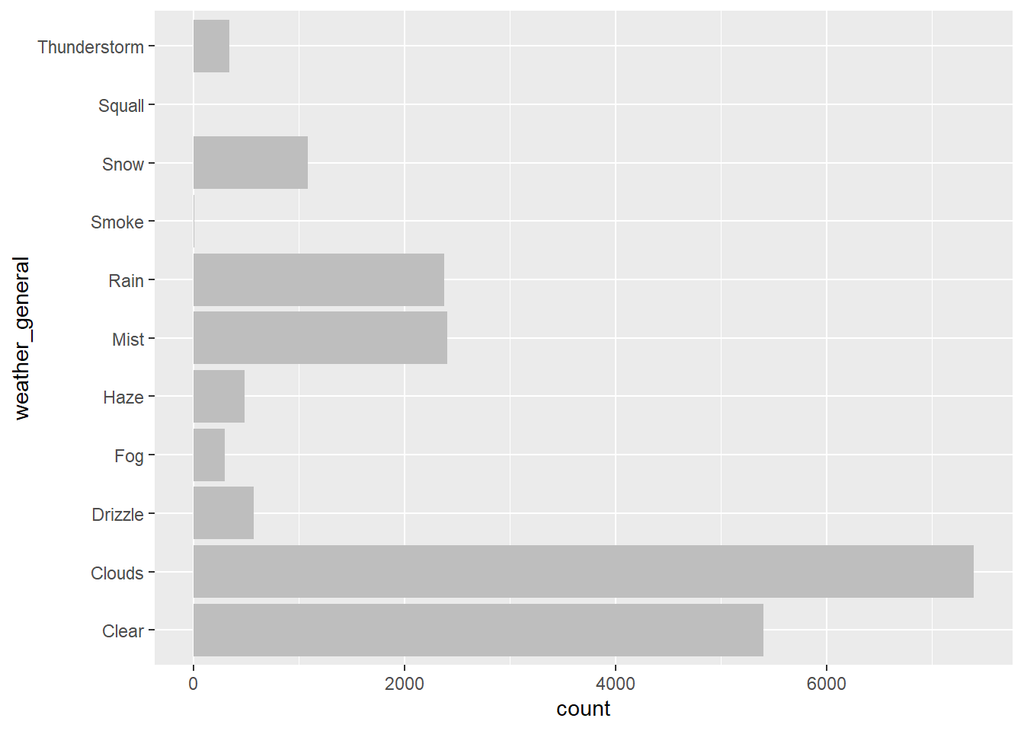

```r
ggplot(traffic_train_train, aes(x = weather_general)) + geom_bar(fill = "grey")+ coord_flip()
```

```r
traffic_train_train$weather_general2 <- traffic_train_train$weather_general
traffic_train_train$weather_general2[traffic_train_train$weather_general2 == "Smoke"] <- "Haze"
traffic_train_train$weather_general2[traffic_train_train$weather_general2 == "Squall"] <- "Thunderstorm"
traffic_train_train$weather_general2 <- droplevels(traffic_train_train$weather_general2)

traffic_train_test$weather_general2 <- traffic_train_test$weather_general
traffic_train_test$weather_general2[traffic_train_test$weather_general2 == "Smoke"] <- "Haze"
traffic_train_test$weather_general2[traffic_train_test$weather_general2 == "Squall"] <- "Thunderstorm"
traffic_train_test$weather_general2 <- droplevels(traffic_train_test$weather_general2)

traffic_test$weather_general2 <- traffic_test$weather_general
traffic_test$weather_general2[traffic_test$weather_general2 == "Smoke"] <- "Haze"
traffic_test$weather_general2[traffic_test$weather_general2 == "Squall"] <- "Thunderstorm"
traffic_test$weather_general2 <- droplevels(traffic_test$weather_general2)
```

After checking the structure of the yearweek feature, we noticed that only a few observations were recorded in the yearweek no. 53, we combined this level with the no. 52.

```r
table(traffic_train_train$yearweek)
```

```
##
##  00  01  02  03  04  05  06  07  08  09  10  11  12  13  14  15  16  17  18  19
## 198 344 359 313 303 322 375 341 351 343 293 327 350 346 426 411 379 263 395 392
##  20  21  22  23  24  25  26  27  28  29  30  31  32  33  34  35  36  37  38  39
## 458 380 409 296 152 328 482 588 523 495 432 449 338 389 253 286 338 320 311 389
##  40  41  42  43  44  45  46  47  48  49  50  51  52  53
## 450 465 390 296 425 461 488 445 565 579 523 531 314   0
```

```r
traffic_train_train$yearweek[traffic_train_train$yearweek == "53"] <- "52"
traffic_train_train$yearweek <- droplevels(traffic_train_train$yearweek)

traffic_train_test$yearweek[traffic_train_test$yearweek == "53"] <- "52"
traffic_train_test$yearweek <- droplevels(traffic_train_test$yearweek)

traffic_test$yearweek[traffic_test$yearweek == "53"] <- "52"
traffic_test$yearweek <- droplevels(traffic_test$yearweek)
```

#### Removing outliers

We found one outlier in our traffic dataset - with the temperature below -200C. We decided to remove this observation, as it was most likely an error.

```r
out_temp <- which(traffic_train_train$temperature > -200)
traffic_train_train <- traffic_train_train[out_temp,]
```

### Feature engeneering

To transform our positively skewed dependent variable to a relatively symmetrical distribution, we used a Box-Cox transformation.

```r
traffic_boxcox <- boxcox(traffic_train_train$traffic +1, standardize = FALSE)
```

Our optimal lambda results:

```
## [1] 0.6703624
```

```r
traffic_train_train$traffic_boxcox <- traffic_boxcox$x.t
traffic_train_test$traffic_boxcox <- predict(traffic_boxcox,
                                             newdata = traffic_train_test$traffic)
```

We can compare the results of transformation below. Although The new distribution is not ideally symmetrical, the predictive power of our model should still improve.

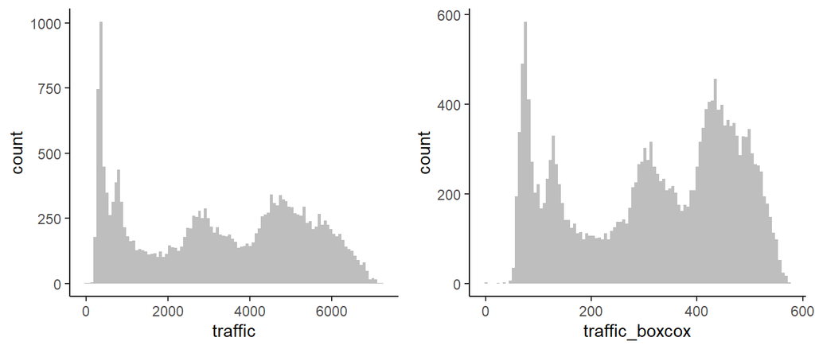

We used the cut() function to divide the following variables into bigger groups: clouds_coverage_pct, months and time.

As for the clouds_coverage_pct, we divided the observations into groups based on their quantiles: [0-1], (1-40], (4-75], (75-90], (90-100].

```r
traffic_train_train$clouds_pct_qntls <-
  cut(traffic_train_train$clouds_coverage_pct,
      breaks = quantile(traffic_train_train$clouds_coverage_pct,
                        probs = seq(0, 1, 0.2)),
      include.lowest = TRUE)

traffic_train_test$clouds_pct_qntls <-
  cut(traffic_train_test$clouds_coverage_pct,
      breaks= c(0,1,40,75,90,100),
      include.lowest = TRUE,
      ordered_result = TRUE)

traffic_test$clouds_pct_qntls <-
  cut(traffic_test$clouds_coverage_pct,
      breaks= c(0,1,40,75,90,100),
      include.lowest = TRUE,
      ordered_result = TRUE)
```

Months were divided into the 4 natural seasons: spring, summer, fall and winter. We also checked if the months had similar traffic mean for each season.

```r
traffic_train_train %>%
  group_by(month) %>%
  summarise(AvgTraffic_bc=mean(traffic, na.rm=T),
            Count=n()) %>%
  arrange(desc(AvgTraffic_bc))
```

```
## # A tibble: 12 x 3
##    month AvgTraffic_bc Count
##    <fct>         <dbl> <int>
##  1 08            3467.  1578
##  2 10            3458.  1827
##  3 06            3402.  1355
##  4 05            3339.  1800
##  5 04            3324.  1567
##  6 07            3317.  2271
##  7 09            3296.  1271
##  8 03            3269.  1451
##  9 11            3192.  1966
## 10 02            3128.  1414
## 11 01            3067.  1484
## 12 12            2932.  2385
```

The binning of the time feature was based on the graph and mean traffic values analysis. We decided to create five levels: “morning”,“midday”,“afternoon”,“evening” and “night”, corresponding with the following hours: [6-10],[11-14],[15-17],[18-21],[22-5].

```r
traffic_train_train %>%
  group_by(time) %>%
  summarise(AvgTraffic_bc=mean(traffic, na.rm=T),
            Count=n()) %>%
  arrange(desc(AvgTraffic_bc)) %>% print(n = Inf)
```

```
## # A tibble: 24 x 3
##    time  AvgTraffic_bc Count
##    <fct>         <dbl> <int>
##  1 16            5652.   868
##  2 17            5331.   832
##  3 15            5313.   817
##  4 14            5004.   848
##  5 13            4764.   808
##  6 12            4753.   824
##  7 07            4630.   874
##  8 08            4555.   891
##  9 11            4494.   799
## 10 09            4347.   835
## 11 18            4294.   828
## 12 10            4172.   873
## 13 06            4076.   875
## 14 19            3263.   835
## 15 20            2823.   855
## 16 21            2671.   843
## 17 22            2182.   852
## 18 05            1993.   854
## 19 23            1448.   876
## 20 00             802.   850
## 21 04             662.   893
## 22 01             502.   854
## 23 02             379.   855
## 24 03             364.   830
```

```r
traffic_train_train %>%
  group_by(yearweek) %>%
  summarise(AvgTraffic_bc=mean(traffic, na.rm=T),
            Count=n()) %>%
  arrange(desc(AvgTraffic_bc))
```

```
## # A tibble: 53 x 3
##    yearweek AvgTraffic_bc Count
##    <fct>            <dbl> <int>
##  1 42               3656.   390
##  2 34               3572.   253
##  3 17               3569.   263
##  4 33               3527.   389
##  5 30               3519.   432
##  6 31               3469.   449
##  7 22               3452.   409
##  8 38               3452.   311
##  9 20               3447.   458
## 10 19               3439.   392
## # ... with 43 more rows
```

### Variables selection

In the next step, we removed the columns that we decided not to use in our analyses.

```r
other_col <- c("date_time", "clouds_coverage_pct", "DateT", "date", "weekend","weather-detailed")
traffic_variables_all <- colnames(traffic_train_train)
traffic_variables_in <- traffic_variables_all[!(traffic_variables_all %in% other_col)]
```

All of the column names were divided into two groups according to their type: numeric or factor.

```r
traffic_numeric_vars <-
  sapply(traffic_train_train[,which(colnames(traffic_train_train) %in% traffic_variables_in)], is.numeric) %>%
  which() %>%
  names()

traffic_factor_vars <-
  sapply(traffic_train_train[,which(colnames(traffic_train_train) %in% traffic_variables_in)], is.factor) %>%
  which() %>%
  names()
```

Using the first group we calculated the correlation matrix. The most correlated feature with the traffic level is temperature. It shouldn’t surprise us that the temperature is also correlated with the amount of rain reported and year (global warming).

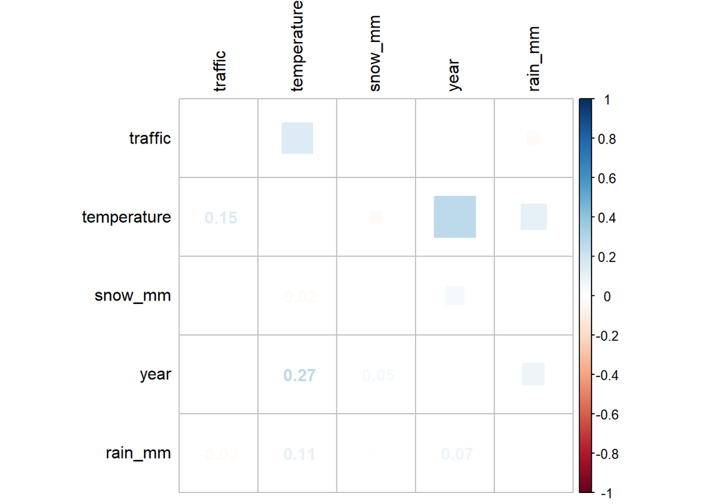

We measured the strength of the relationships between features and the target variable using the ANOVA models.

```
##            time2             time          weekend          weekday
##     12424.312130      2948.586662      1127.516406       206.363033
## clouds_pct_qntls           season weather_general2  weather_general
##        43.161322        33.796206        28.250786        22.904358
##            month         yearweek
##        12.219413         5.121612
```

We had two groups of similar variables: weekend / weekday and month / yearweek / season based on the anova analysis we’ll leave weekend and season which F statistics is higher

The strongest relations with the target variable were presented using boxplots.

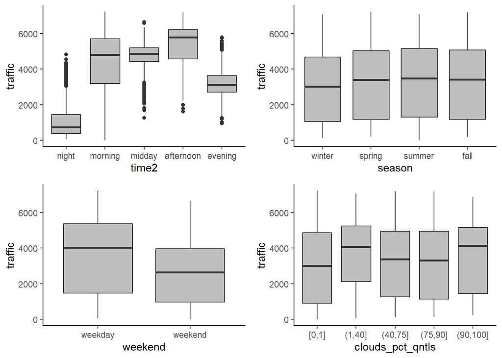

#### Zero or near zero variance

Only two predictors were classified as the near-variance features - rain_mm and snow_mm. As presented above the snow was a very rare event in our dataset. Changing it into a binary variable would have not been very productive, as a similar characteristic was already defined as a level (weather_general feature). Rain_mm was a more informative variable, so we decided to leave it in our model.

```
##               variable   freqRatio percentUnique zeroVar   nzv
## 1              snow_mm 1452.071429   0.049094212   FALSE  TRUE
## 2              rain_mm   31.255575   1.502282881   FALSE  TRUE
## 3              weekend    2.487245   0.009818842   FALSE FALSE
## 4     weather_detailed    2.028582   0.166920320   FALSE FALSE
## 5                 year    1.790178   0.019637685   FALSE FALSE
## 6                time2    1.578657   0.024547106   FALSE FALSE
## 7      weather_general    1.370597   0.054003633   FALSE FALSE
## 8     weather_general2    1.370597   0.044184791   FALSE FALSE
## 9  clouds_coverage_pct    1.331985   0.294565271   FALSE FALSE
## 10         temperature    1.240385   2.970199813   FALSE FALSE
## 11                date    1.208955   4.212283372   FALSE FALSE
## 12    clouds_pct_qntls    1.165720   0.024547106   FALSE FALSE
## 13             traffic    1.083333  29.819824243   FALSE FALSE
## 14      traffic_boxcox    1.083333  29.819824243   FALSE FALSE
## 15               month    1.050198   0.058913054   FALSE FALSE
## 16            yearweek    1.015544   0.260199322   FALSE FALSE
## 17              season    1.015181   0.019637685   FALSE FALSE
## 18                time    1.002245   0.117826108   FALSE FALSE
## 19             weekday    1.000678   0.034365948   FALSE FALSE
## 20           date_time    1.000000  85.988511954   FALSE FALSE
## 21               DateT    1.000000  85.988511954   FALSE FALSE
```

Taking all results into account we decided to create 3 sets of variables and test their performance.

The first one was based on the grouped features, the second one used mostly ungrouped features and the third one was mixed.

```r
selected1 <- c("weather_general2","clouds_pct_qntls", "temperature", "rain_mm",
               "time2", "season", "year", "weekend","traffic", "traffic_boxcox")

selected2 <- c("weather_general2","clouds_pct_qntls", "temperature", "rain_mm",
               "time", "month", "year", "weekday", "yearweek", "traffic", "traffic_boxcox")

selected3 <- c("weather_general2","clouds_pct_qntls", "temperature", "rain_mm",
               "time2", "season", "year", "weekend","traffic", "traffic_boxcox", "yearweek")
```

### Cross-validation and performance measurement

Because traffic dataset contained a time series data, we decided to use a time-based split for cross-validation. Using a “timeslice” method the test sample was divided into 5 slices, each containing 8000 observations.

```r
options(contrasts = c("contr.treatment",  # for non-ordinal factors
                      "contr.treatment")) # for ordinal factors

myTimeControl <- trainControl(method = "timeslice",
                              initialWindow = 6000,
                              horizon = 2000,
                              fixedWindow = TRUE,
                              skip=3000)
```

To calculate the model error for both training and test sample, we used the following function:

```r
regressionMetrics <- function(real, predicted) {
  # Mean Square Error
  MSE <- mean((real - predicted)^2)
  # Root Mean Square Error
  RMSE <- sqrt(MSE)
  # Mean Absolute Error
  MAE <- mean(abs(real - predicted))
  # Mean Absolute Percentage Error
  MAPE <- mean(abs(real - predicted)/real)
  # R2
  R2 <- cor(predicted, real)^2

  result <- data.frame(MSE, RMSE, MAE, MAPE, R2)
  return(result)
}
```

### Linear regression

We calculated 4 simple linear models using different sets of features defined above. We also run one model with the defendant variable before the Box-Cox transformation.

lm1 - traffic_boxcox ~ selected1 lm2 - traffic ~ selected1 lm3 - traffic_boxcox ~ selected2 lm4 - traffic_boxcox ~ selected3

Looking at MAPE results, we can conclude that the best results were obtained using the last model, however adding ungrouped featured allowed to obtain better R2 of our model.

```
##                MSE     RMSE      MAE      MAPE        R2
## lm1_train 885835.8 941.1885 714.7897 0.7326474 0.7812660
## lm1_test  925635.6 962.0996 736.3440 4.9777254 0.7567385
## lm2_train 931806.4 965.3012 746.3848 0.8235328 0.7688368
## lm2_test  965415.2 982.5554 765.9478 5.0816102 0.7466413
## lm3_train 580306.9 761.7787 537.3571 0.5696707 0.8569695
## lm3_test  654918.0 809.2700 585.1579 4.8699634 0.8272478
## lm4_train 859049.3 926.8491 707.9944 0.7253269 0.7878919
## lm4_test  907559.6 952.6593 731.0286 4.7954077 0.7614966
```

```r
summary(traffic_lm4)
```

```
##
## Call:
## lm(formula = .outcome ~ ., data = dat)
##
## Residuals:
##     Min      1Q  Median      3Q     Max
## -356.87  -40.39   -0.02   43.47  342.37
##
## Coefficients:
##                                Estimate Std. Error t value Pr(>|t|)
## (Intercept)                  4253.22691 1199.02912   3.547 0.000390 ***
## temperature                     0.79561    0.09790   8.127 4.64e-16 ***
## rain_mm                        -2.22291    0.40726  -5.458 4.87e-08 ***
## year                           -2.03188    0.59480  -3.416 0.000636 ***
## yearweek01                     -0.17647    6.51330  -0.027 0.978385
## yearweek02                      7.79476    6.46046   1.207 0.227626
## yearweek03                      9.07884    6.62494   1.370 0.170577
## yearweek04                      6.71913    6.75254   0.995 0.319722
## yearweek05                     14.95855    6.59793   2.267 0.023391 *
## yearweek06                     14.61793    6.40877   2.281 0.022563 *
## yearweek07                    -11.01736    6.52155  -1.689 0.091162 .
## yearweek08                     21.07676    6.51426   3.235 0.001216 **
## yearweek09                     30.44976   10.61912   2.867 0.004142 **
## yearweek10                     30.34066   11.24103   2.699 0.006958 **
## yearweek11                     31.18104   11.15612   2.795 0.005195 **
## yearweek12                     22.85395   11.11671   2.056 0.039813 *
## yearweek13                     23.40615   11.12614   2.104 0.035416 *
## yearweek14                     24.64134   11.00826   2.238 0.025203 *
## yearweek15                     22.63594   11.01014   2.056 0.039803 *
## yearweek16                     24.09779   11.09395   2.172 0.029856 *
## yearweek17                     31.37409   11.37744   2.758 0.005828 **
## yearweek18                     19.95864   11.13451   1.793 0.073067 .
## yearweek19                     20.83682   11.14984   1.869 0.061665 .
## yearweek20                     16.51922   11.08239   1.491 0.136087
## yearweek21                      4.48196   11.25624   0.398 0.690505
## yearweek22                     14.84134   10.93925   1.357 0.174890
## yearweek23                      2.72978   11.65555   0.234 0.814829
## yearweek24                     -0.33220   12.43726  -0.027 0.978691
## yearweek25                      8.84436   11.64626   0.759 0.447612
## yearweek26                    -21.50258   11.40428  -1.885 0.059379 .
```

[output cut: 37 more lines]

```
## `clouds_pct_qntls(75,90]`      -6.68241    2.56900  -2.601 0.009297 **
## `clouds_pct_qntls(90,100]`      0.21928    3.73835   0.059 0.953227
## seasonspring                  -12.94289    9.02461  -1.434 0.151537
## seasonsummer                    0.04644    9.10227   0.005 0.995929
## seasonfall                      1.50903    6.79149   0.222 0.824165
## time2morning                  254.74998    1.41119 180.522  < 2e-16 ***
## time2midday                   283.29684    1.59871 177.204  < 2e-16 ***
## time2afternoon                322.13069    1.76565 182.443  < 2e-16 ***
## time2evening                  183.88061    1.56683 117.358  < 2e-16 ***
## ---
## Signif. codes:  0 '***' 0.001 '**' 0.01 '*' 0.05 '.' 0.1 ' ' 1
##
## Residual standard error: 72.53 on 20293 degrees of freedom
## Multiple R-squared:  0.7715, Adjusted R-squared:  0.7706
## F-statistic: 913.4 on 75 and 20293 DF,  p-value: < 2.2e-16
```

### KNN

The KNN model was based on the third feature selection. The predicted error was the lowest among the calculated KNN models. Our first hyperparameter k is defined by the square root of 20k observation we were using ~ 141.

```r
different_k3 <- data.frame(k = seq(1, 150, 10))

traffic_knn3 <-
  train(traffic_boxcox ~ .,
        data = traffic_var3_train %>%
          # we exclude traffic
          dplyr::select(-traffic)
        ,
        # model type - now knn!!
        method = "knn",
        # validation used!
        trControl = myTimeControl,
        # parameters to be compared
        tuneGrid = different_k3,
        metric = "RMSE",
        preProcess = c("range"))
```

In the second step we narrowed the range for our parameter k.

```r
different_k3b <- data.frame(k = seq(1,20, 1))

traffic_knn3b <-
  train(traffic_boxcox ~ .,
        data = traffic_var3_train %>%
          # we exclude traffic
          dplyr::select(-traffic)
        ,
        # model type - now knn!!
        method = "knn",
        # validation used!
        trControl = myTimeControl,
        # parameters to be compared
        tuneGrid = different_k3b,
        metric = "RMSE",
        preProcess = c("range"))
```

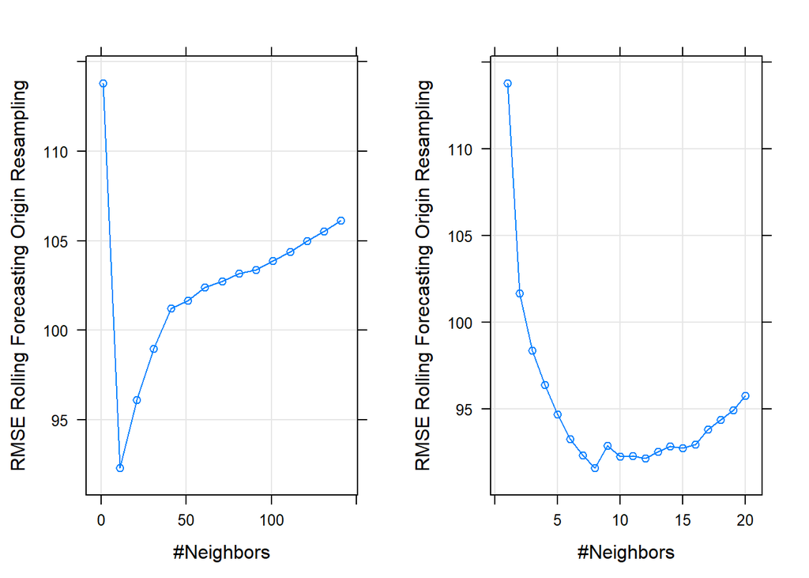

```
##                 MSE     RMSE       MAE      MAPE        R2
## knn3b_train 1333050 1154.578  839.7655 0.6223464 0.6955796
## knn3b_test  1989179 1410.382 1061.1688 4.5160543 0.5026819
```

### LASSO Regression and Elastic net

The Lasso regression performs a regularization, which adds a penalty equal to the absolute value of the magnitude of coefficients. It encourages simple models with fewer parameters. At the beginning we checked the lambda parameters from 10 to 1000.

```r
parameters_lasso <- expand.grid(alpha = 1,
                                lambda = seq(10, 1e3, 10))

set.seed(123456789)

traffic_lasso1 <-  train(traffic_boxcox ~ .,
                         data = traffic_var3_train %>%
                           # we exclude traffic
                           dplyr::select(-traffic)
                         ,
                         method = "glmnet",
                         tuneGrid = parameters_lasso,
                         trControl = myTimeControl)
```

The smallest results are observed in the very left tail of our graph, therefore, we decreased to narrow our lambda range to see the details.

```r
parameters_lasso2 <- expand.grid(alpha = 1,
                                lambda = seq(0, 100, 1))
set.seed(123456789)

traffic_lasso2 <-  train(traffic_boxcox ~ .,
                         data = traffic_var3_train %>%
                           # we exclude traffic
                           dplyr::select(-traffic)
                         ,
                         method = "glmnet",
                         tuneGrid = parameters_lasso2,
                         trControl = myTimeControl)
```

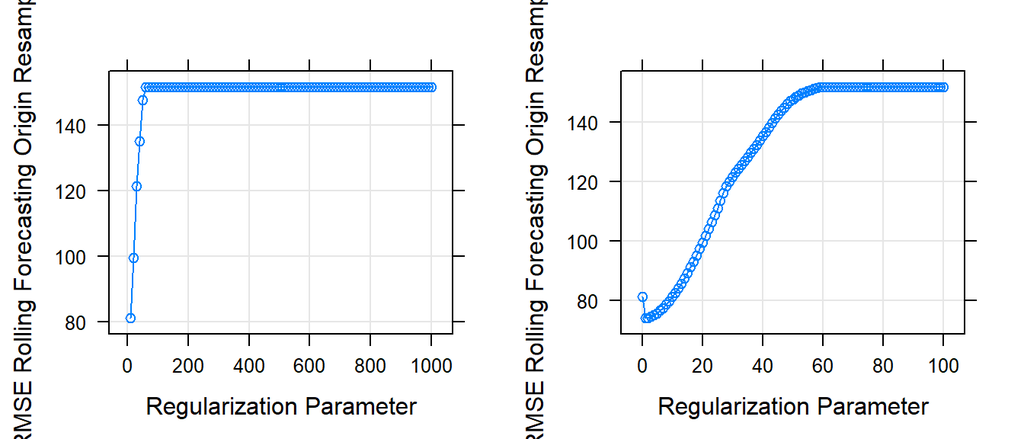

```r
g1 <- plot(traffic_lasso1)
g2 <- plot(traffic_lasso2)
grid.arrange(g1,g2,ncol=2)
```

```r
traffic_lasso2$bestTune
```

```
##   alpha lambda
## 2     1      1
```

The smallest error was obtained for a very small lambda, almost equal to 0. Which means that the OLS (Ordinary Least Squares) solution was probably within the budget created by the lasso regression and the OLS model results were very close to the LASSO regression results.

We also checked if the elastic net approach would have given us better results.

```r
parameters_elastic <- expand.grid(alpha = seq(0, 1, 0.2),
                                  lambda = seq(0, 1e2, 1))
set.seed(123456789)

traffic_elastic1 <- train(traffic_boxcox ~ .,
                          data = traffic_var3_train %>%
                            # we exclude traffic
                            dplyr::select(-traffic)
                          ,
                          method = "glmnet",
                          tuneGrid = parameters_elastic,
                          trControl = myTimeControl)
```

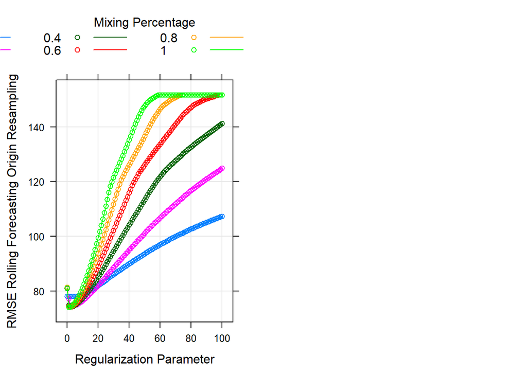

```r
g1 <- plot(traffic_elastic1)

grid.arrange(g1,ncol=2)
```

```r
traffic_lasso1$bestTune
```

```
##   alpha lambda
## 1     1     10
```

The results we obtained were not very satisfying.

```
##                    MSE     RMSE      MAE      MAPE        R2
## lasso_train   874329.1 935.0557 716.2518 0.7444652 0.7851502
## lasso_test    912991.8 955.5061 735.0227 5.1528442 0.7590581
## elastic_train 887197.5 941.9116 724.7131 0.7586082 0.7833375
## elastic_test  916976.7 957.5890 738.8965 5.2713062 0.7578027
```

### Model comparison and selection

```
##                     MSE      RMSE       MAE      MAPE        R2
## lm_train       859049.3  926.8491  707.9944 0.7253269 0.7878919
## knn_train     1333049.6 1154.5777  839.7655 0.6223464 0.6955796
## lasso_train    874329.1  935.0557  716.2518 0.7444652 0.7851502
## elastic_train  887197.5  941.9116  724.7131 0.7586082 0.7833375
## lm_test        907559.6  952.6593  731.0286 4.7954077 0.7614966
## knn_test      1989178.6 1410.3824 1061.1688 4.5160543 0.5026819
## lasso_test     912991.8  955.5061  735.0227 5.1528442 0.7590581
## elastic_test   916976.7  957.5890  738.8965 5.2713062 0.7578027
```

The interpretation of the results was not straightforward. For MAPE, the KNN model turned out to be the most optimal. On the other hand, it achieved a small R2 as well as high absolute errors. If we took a different measure as selection criteria, then probably the linear model would be the optimal one.

At the end we decided to use for forecasting the KNN model with k=8.

The comparison between the predicted and real traffic values, for both the train and the test sample, is presented below:

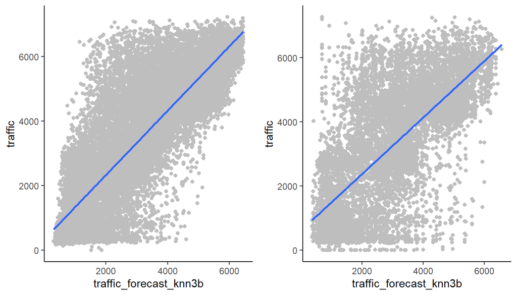

It is worth mentioning that the error measured on the test sample was much higher than on the the training data. Therefore we don’t expect the results to be very accurate, the MAPE will probably be close to 5.